title: Programa Monitora - Protocolo Florestal Global Módulo básico, Alvo Mamíferos terrestres de médio e grande porte Reserva Extrativista Cazumbá-Iracema author: “Elildo Carvalho Jr<sup>1</sup>” date: “<sup>1</sup>Centro Nacional de Pesquisa e Conservação de Mamíferos Carnívoros - ICMBio/CENAP, elildo.carvalho-junior@icmbio.gov.br” output: pdf_document: latex_engine: xelatex html_document: df_print: paged bibliography: “/home/elildojr/Documents/r/Programa-Monitora-Florestal-Global/report/My Collection.bib” csl: “http://www.zotero.org/styles/biological-conservation” linestretch: 1.5 header-includes: -

## Apresentação

Este relatório apresenta resultados do Programa Monitora, Subprograma Terrestre, Componente Florestal Global, Alvo Mamíferos terrestres de médio e grande porte, protocolo básico, na **Reserva Extrativista Cazumbá-Iracema**. O trabalho teve como objetivo descrever a variação anual nas populações de espécies selecionadas, e identificar se elas estão estáveis ou se há tendências significativas de declínio ou aumento populacional.

Ressalta-se que o relatório visa somente descrever os padrões observados. Especulações sobre possíveis causas para esses padrões fogem ao escopo deste documento. Recomenda-se que os resultados sejam debatidos entre comunidades locais, gestores e pesquisadores.

## Métodos

O protocolo básico para o alvo Mamíferos terrestres de médio e grande porte prevê amostragens anuais pelo método de transecções lineares [@Peres1999]. Resumidamente, dois observadores percorrem as transecções a uma velocidade constante e registram, para cada observação, a espécie, número de indivíduos e distãncia perperndicular entre o primeiro indivíduo avistado e o centro da trilha. Cada UC deve ter pelo menos três transectos de 5 km e o esforço anual mínimo, combinando todos os transectos, deve ser de 150 km [@Nobre2015]. Os dados obtidos são utilizados para estimar índices populacionais para as espécies-alvo, como taxa de encontro (indivíduos ou grupos avistados a cada 10 km percorridos) ou densidade (individuos ou grupos por km2).

A validade do modelo depende das seguintes premissas:

1. o índice populacional (taxa de encontro) segue trajetória paralela ao tamanho real da população.
2. a probabilidade de detecção de cada espécie permanece constante ao longo do tempo.
3. o tamanho do grupo de cada espécie permanece constante ao longo do tempo.
4. as distâncias perpendiculares para cada espécie permanecem constante ao longo do tempo.

A validade de pelo menos algumas dessas premissas pode ser testada com os próprios dados (e.g., constância no tamanho de grupo e nas distâncias perpendiculares). Isso seá feito em relatórios futuros. Por ora, assume-se que as premissas são válidas.

Uma descrição detalhada do modelo está disponível no anexo 1.

## Resultados e discussão

A taxa de média de crescimento estocástico de todas as espécies não foi significativamente diferente de zero, indicando que todas se mantiveram estáveis durante o período de monitoramento (Tabela 1). No entanto, a maioria das taxas foi levemente negativa (Tabela 1, Figuras 1 a 8). Ressalta-se que os intervalos de confiança foram relativamente altos, indicando incerteza nas estimativas. Isso é um reflexo da variabilidade do sistema e do esforço amostral insuficiente para detectar tendências populacionais sutis, ao menos em prazos muito curtos. A continuação do monitoramento poderá eventualmente revelar se as leves tendências de declínio são reais ou meros artefatos da amostragem.

Ressalta-se que o modelo fornece uma estimativa *suavizada* do índice populacional, mas não corrige erros decorrentes de variações na taxa de detecção [@kery2011bayesian]. Pelo menos para algumas espécies mais comuns, pode ser viável uma correção na taxa de detecção a partir das distâncias perpendiculares. Isso será avaliado em relatórios futuros.

Taxa estocástica de crescimento populacional, intervalo de confiança e tendência populacional para espécies selecionadas da RESEX Cazumbá-Iracema

| Especies | r.medio | IC | tendencia |
| --- | --- | --- | --- |
| Cebus | 0.10 | (-0.56 a 0.73) | estável |
| Dasyprocta | -0.06 | (-0.65 a 0.54) | estável |
| Mazama | -0.16 | (-0.73 a 0.37) | estável |
| Myoprocta | -0.11 | (-0.62 a 0.42) | estável |
| Pecari | -0.09 | (-0.62 a 0.42) | estável |
| Saguinus | 0.13 | (-0.46 a 0.73) | estável |
| Sapajus | -0.04 | (-0.46 a 0.36) | estável |
| Urosciurus | -0.07 | (-0.56 a 0.43) | estável |

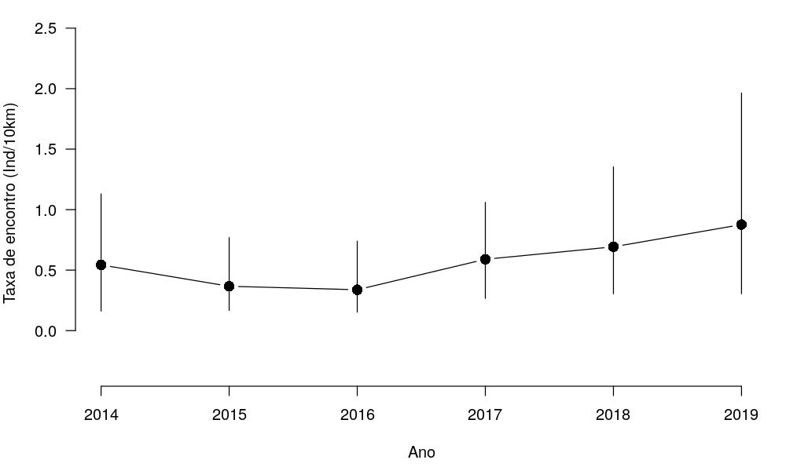

Taxa de encontro anual para Cebus albifrons. As barras verticais indicam a incerteza associada à estimativa (intervalo de confiança de 95%)

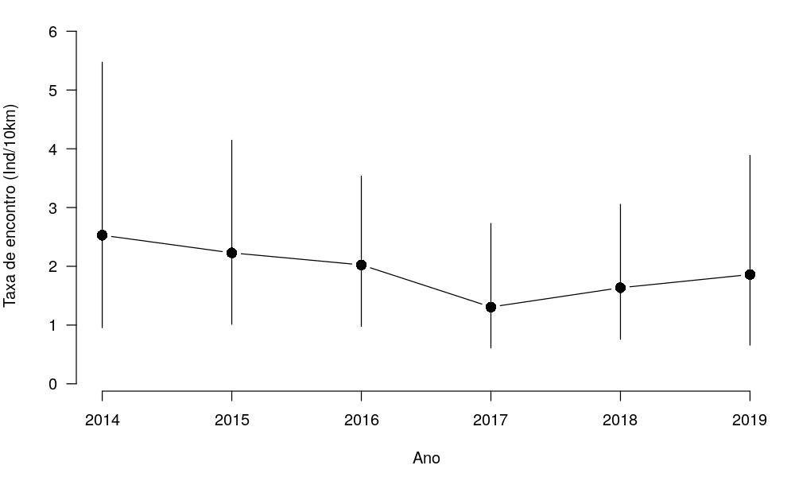

Taxa de encontro anual para Dasyprocta fuliginosa. As barras verticais indicam a incerteza associada à estimativa (intervalo de confiança de 95%)

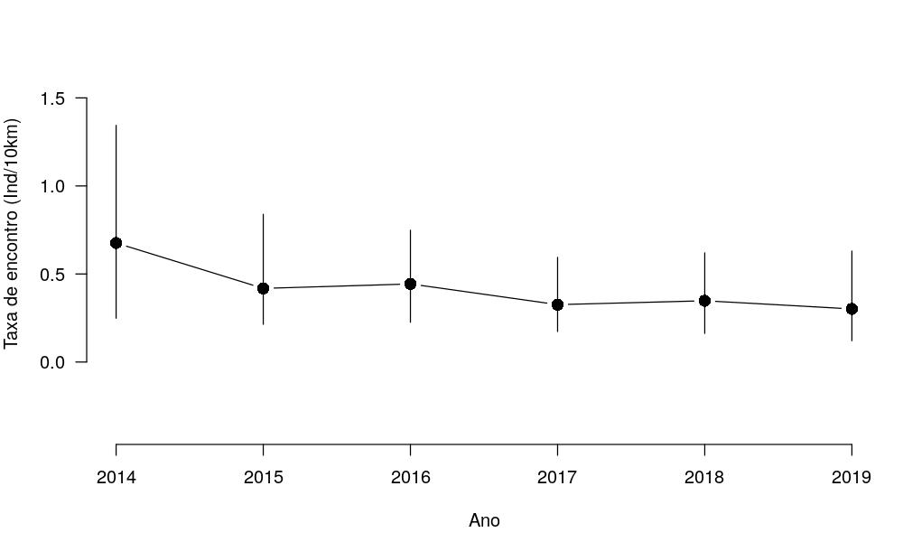

Taxa de encontro anual para Mazama americana. As barras verticais indicam a incerteza associada à estimativa (intervalo de confiança de 95%)

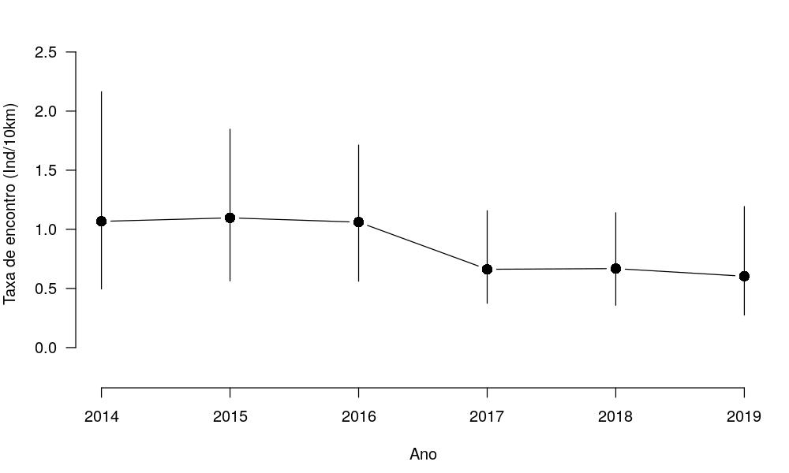

Taxa de encontro anual para Myoprocta pratti. As barras verticais indicam a incerteza associada à estimativa (intervalo de confiança de 95%)

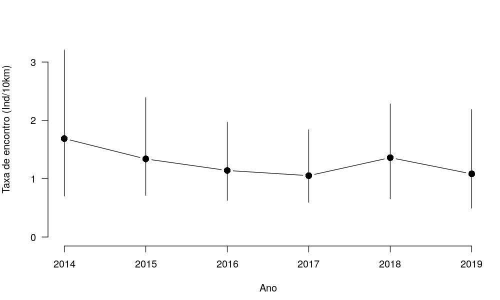

Taxa de encontro anual para Pecari tajacu. As barras verticais indicam a incerteza associada à estimativa (intervalo de confiança de 95%)

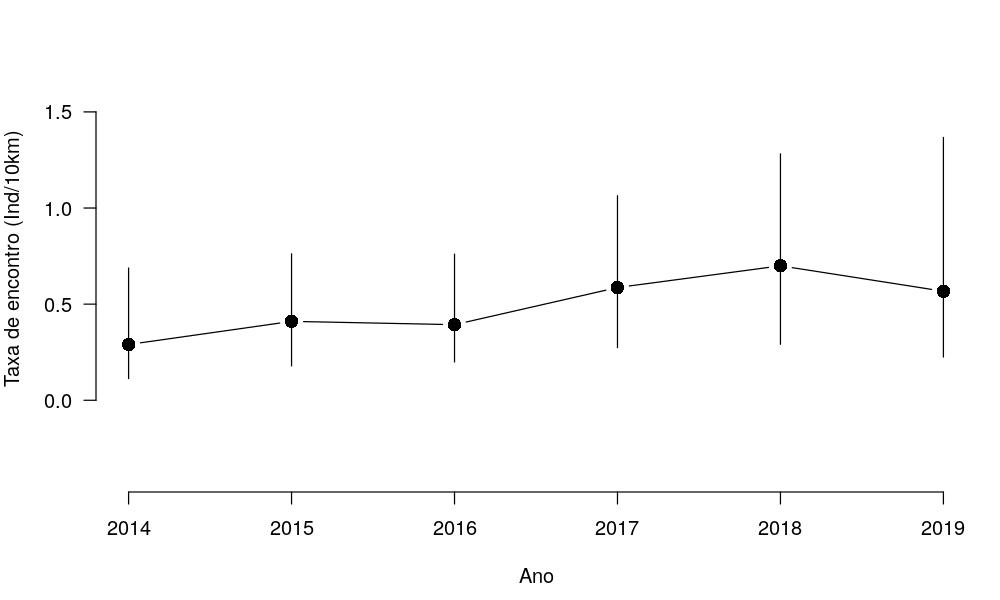

Taxa de encontro anual para Saguinus weddelli. As barras verticais indicam a incerteza associada à estimativa (intervalo de confiança de 95%)

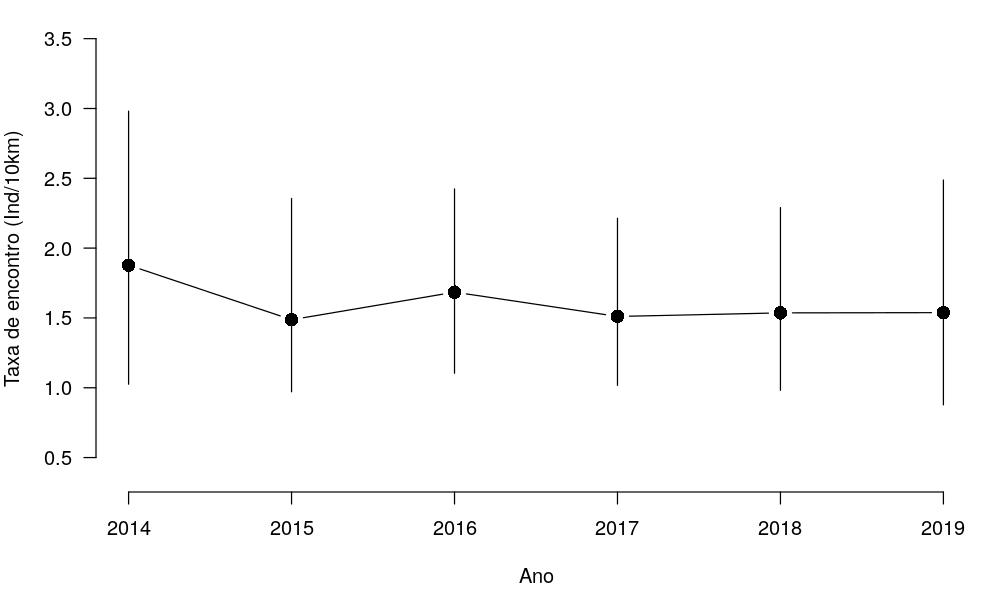

Taxa de encontro anual para Sapajus macrocephalus. As barras verticais indicam a incerteza associada à estimativa (intervalo de confiança de 95%)

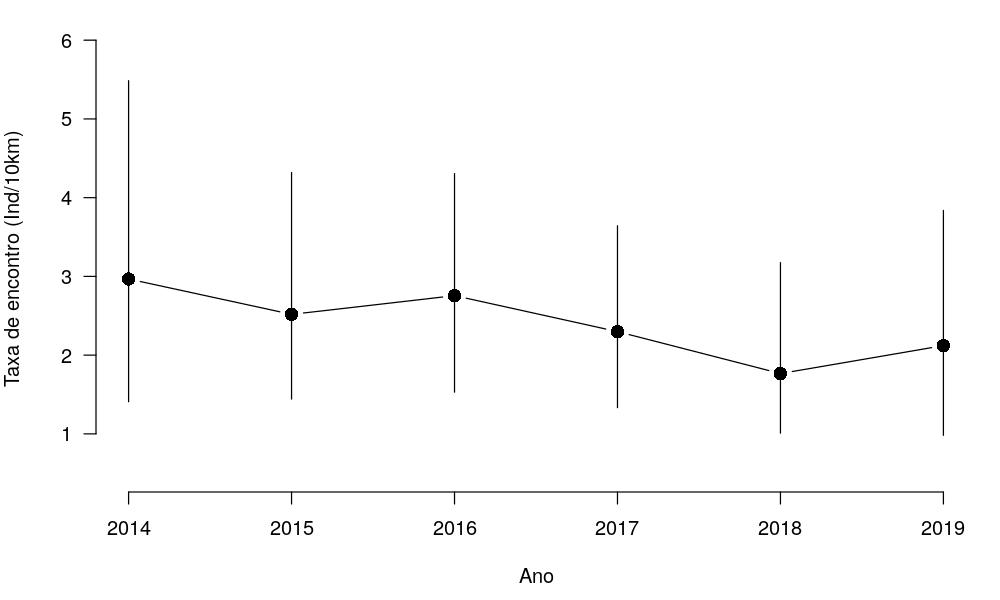

Taxa de encontro anual para Urosciurus spadiceus. As barras verticais indicam a incerteza associada à estimativa (intervalo de confiança de 95%)

## Anexo 1

Foi ajustado um modelo estocástico de dinâmica populacional aos dados. O modelo particiona a variação nas observações em um componente associado ao processo ecológico (variações aleatórias nas mudanças populacionais) e um componente associado ao processo de observação (erros nas estimativas de abundância). No modelo, o tamanho da população (nesse caso, o índice populacional = taxa de encontro) em determinado ano depende do tamanho da população no ano anterior. As taxas anuais de crescimento populacional são vistas como realizações de um processo aleatório com distribuição normal centrada na taxa de crescimento médio para todo o período considerado e variância correspondente à estocasticidade ambiental. Da mesma forma, as observações anuais estão sujeitas a erro aleatório com distribuição normal centrada no zero [@kery2011bayesian]. O modelo seguiu as especificações de [@kery2011bayesian] (p. 126-130) e foi implementado no JAGS [@Plummer2015] usando o pacote R2jags [@su2012r2jags].Foram executadas três Cadeias de Markov e Monte Carlo (MCMCM) com 25000 iterações, *burn-in* de 1000 e *thinning rate* de 3. A convergência dos parâmetros foi avaliada pelo diagnóstico de Gelman-Rubin [@Gelman2011]. Todos os dados e códigos utilizados estão disponiveis no repositório https://github.com/ICMBio-CENAP/Programa-Monitora-Florestal-Global.